# Solutions to exercises

Ryan Hill

## Intro Exercises

The following are suggested solutions to the exercises given in the training resources. They are not intended to be the *best* way to do things, by speed or efficiency or even niceness of code, but simply *a* way to get the answer. If you find other ways that get the same answer then that’s great. The questions are designed to get you used to certain concepts so please make sure you have attempted the exercise before looking at the answer, and try tweaking any answers to see how you might answer a similar but different question.

As a final note, for formatting purposes most dataframe outputs have the following custom code after it `%>% nice_format()` to make the output nicer in the html file, you can ignore this, it is just for the purpose of the output document.

1. Assign your job title to a variable called `job_title`, and assign your boss’ name to a variable called `boss`

```r
job_title <- 'Innovation Manager'
boss <- "David Borthwick"
```

We do this using the `<-` assignment operator, and specify strings using either a single or double quote.

2. Create a vector of the numbers 1 to 10 and store it in a variable called `nums`

```r
nums <- 1:10
nums
```

```
##  [1]  1  2  3  4  5  6  7  8  9 10
```

We do this using `:` to produce a sequenced vector from 1 to 10

3. Take that vector and output the square of each number in it

```r
nums**2
```

```
##  [1]   1   4   9  16  25  36  49  64  81 100
```

We do this using the `**` operator which is the exponent operator. As R is vectorised this acts on all elements of `nums`.

4. Output just those elements of the vector that are less than or equal to 4

```r
nums[nums <= 4]
```

```
## [1] 1 2 3 4
```

We are selecting the elements of `nums` by first generating a logical vector using the `nums <= 4` statement.

5. Produce another vector of the numbers -1 to -10 and store it in `neg_nums`. Output the sum between elements of the two vectors i.e. the first element of `nums` + the first element of `neg_nums` etc

```r
neg_nums <- -1:-10
neg_nums
```

```
##  [1]  -1  -2  -3  -4  -5  -6  -7  -8  -9 -10
```

```r
nums + neg_nums
```

```
##  [1] 0 0 0 0 0 0 0 0 0 0
```

We do this by using the same `:` as before but with negative numbers. We then add the vectors element-wise by just using the `+` operator.

6. Generate a vector of numbers, starting at 13, ending at 190, in steps of 17.

```r
seq(13, 190, 17)
```

```
##  [1]  13  30  47  64  81  98 115 132 149 166 183
```

The `seq` function is the solution to this question as it takes a start, an end, and a step argument.

7. Using Google (or another search engine), find a function to generate random values from a normal distribution. Assign to a variable 100,000 randomly generated normally distributed values. What is their mean and what is their standard deviation (another function to look up)?

```r
random_numbers <- rnorm(100000)
mean(random_numbers)
```

```
## [1] 0.00114395
```

```r
sd(random_numbers)
```

```
## [1] 1.002055
```

`rnorm` is the function that generates random numbers from a normal distribution. We would get different values each time we ran this, we can use the `set.seed()` function to set the random seed that we pick from if we need it to be reproducible. By default `rnorm` picks from a distribution with a mean of 0 and a standard deviation of 1.

8. From your answer to question 7, access just the 8th, 9412nd, and 12399th elements of that vector.

```r
random_numbers[c(8, 9412, 12399)]
```

```
## [1]  0.6720609 -0.6390074 -0.5195005
```

We can access many elements of a vector at the same time by passing a vector as the selection criteria.

## `Dplyr` Exercises 1

The following exercises use the built-in `mtcars` dataset. First get familiar with it using the methods described above. Notice that this dataset has rownames rather than just rownumbers.

```r
mtcars %>% nice_format()
```

|  | mpg | cyl | disp | hp | drat | wt | qsec | vs | am | gear | carb |
| --- | --- | --- | --- | --- | --- | --- | --- | --- | --- | --- | --- |
| Mazda RX4 | 21.0 | 6 | 160.0 | 110 | 3.90 | 2.620 | 16.46 | 0 | 1 | 4 | 4 |
| Mazda RX4 Wag | 21.0 | 6 | 160.0 | 110 | 3.90 | 2.875 | 17.02 | 0 | 1 | 4 | 4 |
| Datsun 710 | 22.8 | 4 | 108.0 | 93 | 3.85 | 2.320 | 18.61 | 1 | 1 | 4 | 1 |
| Hornet 4 Drive | 21.4 | 6 | 258.0 | 110 | 3.08 | 3.215 | 19.44 | 1 | 0 | 3 | 1 |
| Hornet Sportabout | 18.7 | 8 | 360.0 | 175 | 3.15 | 3.440 | 17.02 | 0 | 0 | 3 | 2 |
| Valiant | 18.1 | 6 | 225.0 | 105 | 2.76 | 3.460 | 20.22 | 1 | 0 | 3 | 1 |
| Duster 360 | 14.3 | 8 | 360.0 | 245 | 3.21 | 3.570 | 15.84 | 0 | 0 | 3 | 4 |
| Merc 240D | 24.4 | 4 | 146.7 | 62 | 3.69 | 3.190 | 20.00 | 1 | 0 | 4 | 2 |
| Merc 230 | 22.8 | 4 | 140.8 | 95 | 3.92 | 3.150 | 22.90 | 1 | 0 | 4 | 2 |
| Merc 280 | 19.2 | 6 | 167.6 | 123 | 3.92 | 3.440 | 18.30 | 1 | 0 | 4 | 4 |
| Merc 280C | 17.8 | 6 | 167.6 | 123 | 3.92 | 3.440 | 18.90 | 1 | 0 | 4 | 4 |
| Merc 450SE | 16.4 | 8 | 275.8 | 180 | 3.07 | 4.070 | 17.40 | 0 | 0 | 3 | 3 |
| Merc 450SL | 17.3 | 8 | 275.8 | 180 | 3.07 | 3.730 | 17.60 | 0 | 0 | 3 | 3 |
| Merc 450SLC | 15.2 | 8 | 275.8 | 180 | 3.07 | 3.780 | 18.00 | 0 | 0 | 3 | 3 |
| Cadillac Fleetwood | 10.4 | 8 | 472.0 | 205 | 2.93 | 5.250 | 17.98 | 0 | 0 | 3 | 4 |
| Lincoln Continental | 10.4 | 8 | 460.0 | 215 | 3.00 | 5.424 | 17.82 | 0 | 0 | 3 | 4 |
| Chrysler Imperial | 14.7 | 8 | 440.0 | 230 | 3.23 | 5.345 | 17.42 | 0 | 0 | 3 | 4 |
| Fiat 128 | 32.4 | 4 | 78.7 | 66 | 4.08 | 2.200 | 19.47 | 1 | 1 | 4 | 1 |
| Honda Civic | 30.4 | 4 | 75.7 | 52 | 4.93 | 1.615 | 18.52 | 1 | 1 | 4 | 2 |
| Toyota Corolla | 33.9 | 4 | 71.1 | 65 | 4.22 | 1.835 | 19.90 | 1 | 1 | 4 | 1 |
| Toyota Corona | 21.5 | 4 | 120.1 | 97 | 3.70 | 2.465 | 20.01 | 1 | 0 | 3 | 1 |
| Dodge Challenger | 15.5 | 8 | 318.0 | 150 | 2.76 | 3.520 | 16.87 | 0 | 0 | 3 | 2 |
| AMC Javelin | 15.2 | 8 | 304.0 | 150 | 3.15 | 3.435 | 17.30 | 0 | 0 | 3 | 2 |
| Camaro Z28 | 13.3 | 8 | 350.0 | 245 | 3.73 | 3.840 | 15.41 | 0 | 0 | 3 | 4 |
| Pontiac Firebird | 19.2 | 8 | 400.0 | 175 | 3.08 | 3.845 | 17.05 | 0 | 0 | 3 | 2 |
| Fiat X1-9 | 27.3 | 4 | 79.0 | 66 | 4.08 | 1.935 | 18.90 | 1 | 1 | 4 | 1 |
| Porsche 914-2 | 26.0 | 4 | 120.3 | 91 | 4.43 | 2.140 | 16.70 | 0 | 1 | 5 | 2 |
| Lotus Europa | 30.4 | 4 | 95.1 | 113 | 3.77 | 1.513 | 16.90 | 1 | 1 | 5 | 2 |
| Ford Pantera L | 15.8 | 8 | 351.0 | 264 | 4.22 | 3.170 | 14.50 | 0 | 1 | 5 | 4 |
| Ferrari Dino | 19.7 | 6 | 145.0 | 175 | 3.62 | 2.770 | 15.50 | 0 | 1 | 5 | 6 |
| Maserati Bora | 15.0 | 8 | 301.0 | 335 | 3.54 | 3.570 | 14.60 | 0 | 1 | 5 | 8 |
| Volvo 142E | 21.4 | 4 | 121.0 | 109 | 4.11 | 2.780 | 18.60 | 1 | 1 | 4 | 2 |

```r
#?mtcars
summary(mtcars)
```

```
##       mpg             cyl             disp             hp
##  Min.   :10.40   Min.   :4.000   Min.   : 71.1   Min.   : 52.0
##  1st Qu.:15.43   1st Qu.:4.000   1st Qu.:120.8   1st Qu.: 96.5
##  Median :19.20   Median :6.000   Median :196.3   Median :123.0
##  Mean   :20.09   Mean   :6.188   Mean   :230.7   Mean   :146.7
##  3rd Qu.:22.80   3rd Qu.:8.000   3rd Qu.:326.0   3rd Qu.:180.0
##  Max.   :33.90   Max.   :8.000   Max.   :472.0   Max.   :335.0
##       drat             wt             qsec             vs
##  Min.   :2.760   Min.   :1.513   Min.   :14.50   Min.   :0.0000
##  1st Qu.:3.080   1st Qu.:2.581   1st Qu.:16.89   1st Qu.:0.0000
##  Median :3.695   Median :3.325   Median :17.71   Median :0.0000
##  Mean   :3.597   Mean   :3.217   Mean   :17.85   Mean   :0.4375
##  3rd Qu.:3.920   3rd Qu.:3.610   3rd Qu.:18.90   3rd Qu.:1.0000
##  Max.   :4.930   Max.   :5.424   Max.   :22.90   Max.   :1.0000
##        am              gear            carb
##  Min.   :0.0000   Min.   :3.000   Min.   :1.000
##  1st Qu.:0.0000   1st Qu.:3.000   1st Qu.:2.000
##  Median :0.0000   Median :4.000   Median :2.000
##  Mean   :0.4062   Mean   :3.688   Mean   :2.812
##  3rd Qu.:1.0000   3rd Qu.:4.000   3rd Qu.:4.000
##  Max.   :1.0000   Max.   :5.000   Max.   :8.000
```

```r
str(mtcars)
```

```
## 'data.frame':    32 obs. of  11 variables:
##  $ mpg : num  21 21 22.8 21.4 18.7 18.1 14.3 24.4 22.8 19.2 ...
##  $ cyl : num  6 6 4 6 8 6 8 4 4 6 ...
##  $ disp: num  160 160 108 258 360 ...
##  $ hp  : num  110 110 93 110 175 105 245 62 95 123 ...
##  $ drat: num  3.9 3.9 3.85 3.08 3.15 2.76 3.21 3.69 3.92 3.92 ...
##  $ wt  : num  2.62 2.88 2.32 3.21 3.44 ...
##  $ qsec: num  16.5 17 18.6 19.4 17 ...
##  $ vs  : num  0 0 1 1 0 1 0 1 1 1 ...
##  $ am  : num  1 1 1 0 0 0 0 0 0 0 ...
##  $ gear: num  4 4 4 3 3 3 3 4 4 4 ...
##  $ carb: num  4 4 1 1 2 1 4 2 2 4 ...
```

1. Print out the hp column using the `select()` function.  
   Try using the `pull()` function instead of `select()` to see what the difference is.

```r
mtcars %>% select(hp) %>% nice_format()
```

|  | hp |
| --- | --- |
| Mazda RX4 | 110 |
| Mazda RX4 Wag | 110 |
| Datsun 710 | 93 |
| Hornet 4 Drive | 110 |
| Hornet Sportabout | 175 |
| Valiant | 105 |
| Duster 360 | 245 |
| Merc 240D | 62 |
| Merc 230 | 95 |
| Merc 280 | 123 |
| Merc 280C | 123 |
| Merc 450SE | 180 |
| Merc 450SL | 180 |
| Merc 450SLC | 180 |
| Cadillac Fleetwood | 205 |
| Lincoln Continental | 215 |
| Chrysler Imperial | 230 |
| Fiat 128 | 66 |
| Honda Civic | 52 |
| Toyota Corolla | 65 |
| Toyota Corona | 97 |
| Dodge Challenger | 150 |
| AMC Javelin | 150 |
| Camaro Z28 | 245 |
| Pontiac Firebird | 175 |
| Fiat X1-9 | 66 |
| Porsche 914-2 | 91 |
| Lotus Europa | 113 |
| Ford Pantera L | 264 |
| Ferrari Dino | 175 |
| Maserati Bora | 335 |
| Volvo 142E | 109 |

```r
mtcars %>% pull(hp)
```

```
##  [1] 110 110  93 110 175 105 245  62  95 123 123 180 180 180 205 215 230  66  52
## [20]  65  97 150 150 245 175  66  91 113 264 175 335 109
```

Select returns a dataframe, as where pull returns a vector.

2. Print out the all but hp column using the `select()` function.

```r
mtcars %>% select (-hp) %>% nice_format()
```

|  | mpg | cyl | disp | drat | wt | qsec | vs | am | gear | carb |
| --- | --- | --- | --- | --- | --- | --- | --- | --- | --- | --- |
| Mazda RX4 | 21.0 | 6 | 160.0 | 3.90 | 2.620 | 16.46 | 0 | 1 | 4 | 4 |
| Mazda RX4 Wag | 21.0 | 6 | 160.0 | 3.90 | 2.875 | 17.02 | 0 | 1 | 4 | 4 |
| Datsun 710 | 22.8 | 4 | 108.0 | 3.85 | 2.320 | 18.61 | 1 | 1 | 4 | 1 |
| Hornet 4 Drive | 21.4 | 6 | 258.0 | 3.08 | 3.215 | 19.44 | 1 | 0 | 3 | 1 |
| Hornet Sportabout | 18.7 | 8 | 360.0 | 3.15 | 3.440 | 17.02 | 0 | 0 | 3 | 2 |
| Valiant | 18.1 | 6 | 225.0 | 2.76 | 3.460 | 20.22 | 1 | 0 | 3 | 1 |
| Duster 360 | 14.3 | 8 | 360.0 | 3.21 | 3.570 | 15.84 | 0 | 0 | 3 | 4 |
| Merc 240D | 24.4 | 4 | 146.7 | 3.69 | 3.190 | 20.00 | 1 | 0 | 4 | 2 |
| Merc 230 | 22.8 | 4 | 140.8 | 3.92 | 3.150 | 22.90 | 1 | 0 | 4 | 2 |
| Merc 280 | 19.2 | 6 | 167.6 | 3.92 | 3.440 | 18.30 | 1 | 0 | 4 | 4 |
| Merc 280C | 17.8 | 6 | 167.6 | 3.92 | 3.440 | 18.90 | 1 | 0 | 4 | 4 |
| Merc 450SE | 16.4 | 8 | 275.8 | 3.07 | 4.070 | 17.40 | 0 | 0 | 3 | 3 |
| Merc 450SL | 17.3 | 8 | 275.8 | 3.07 | 3.730 | 17.60 | 0 | 0 | 3 | 3 |
| Merc 450SLC | 15.2 | 8 | 275.8 | 3.07 | 3.780 | 18.00 | 0 | 0 | 3 | 3 |
| Cadillac Fleetwood | 10.4 | 8 | 472.0 | 2.93 | 5.250 | 17.98 | 0 | 0 | 3 | 4 |
| Lincoln Continental | 10.4 | 8 | 460.0 | 3.00 | 5.424 | 17.82 | 0 | 0 | 3 | 4 |
| Chrysler Imperial | 14.7 | 8 | 440.0 | 3.23 | 5.345 | 17.42 | 0 | 0 | 3 | 4 |
| Fiat 128 | 32.4 | 4 | 78.7 | 4.08 | 2.200 | 19.47 | 1 | 1 | 4 | 1 |
| Honda Civic | 30.4 | 4 | 75.7 | 4.93 | 1.615 | 18.52 | 1 | 1 | 4 | 2 |
| Toyota Corolla | 33.9 | 4 | 71.1 | 4.22 | 1.835 | 19.90 | 1 | 1 | 4 | 1 |
| Toyota Corona | 21.5 | 4 | 120.1 | 3.70 | 2.465 | 20.01 | 1 | 0 | 3 | 1 |
| Dodge Challenger | 15.5 | 8 | 318.0 | 2.76 | 3.520 | 16.87 | 0 | 0 | 3 | 2 |
| AMC Javelin | 15.2 | 8 | 304.0 | 3.15 | 3.435 | 17.30 | 0 | 0 | 3 | 2 |
| Camaro Z28 | 13.3 | 8 | 350.0 | 3.73 | 3.840 | 15.41 | 0 | 0 | 3 | 4 |
| Pontiac Firebird | 19.2 | 8 | 400.0 | 3.08 | 3.845 | 17.05 | 0 | 0 | 3 | 2 |
| Fiat X1-9 | 27.3 | 4 | 79.0 | 4.08 | 1.935 | 18.90 | 1 | 1 | 4 | 1 |
| Porsche 914-2 | 26.0 | 4 | 120.3 | 4.43 | 2.140 | 16.70 | 0 | 1 | 5 | 2 |
| Lotus Europa | 30.4 | 4 | 95.1 | 3.77 | 1.513 | 16.90 | 1 | 1 | 5 | 2 |
| Ford Pantera L | 15.8 | 8 | 351.0 | 4.22 | 3.170 | 14.50 | 0 | 1 | 5 | 4 |
| Ferrari Dino | 19.7 | 6 | 145.0 | 3.62 | 2.770 | 15.50 | 0 | 1 | 5 | 6 |
| Maserati Bora | 15.0 | 8 | 301.0 | 3.54 | 3.570 | 14.60 | 0 | 1 | 5 | 8 |
| Volvo 142E | 21.4 | 4 | 121.0 | 4.11 | 2.780 | 18.60 | 1 | 1 | 4 | 2 |

We can use the `-` before a column name in `select` to remove that column.

```r
mtcars %>% select(mpg, vs:gear) %>% nice_format()
```

|  | mpg | vs | am | gear |
| --- | --- | --- | --- | --- |
| Mazda RX4 | 21.0 | 0 | 1 | 4 |
| Mazda RX4 Wag | 21.0 | 0 | 1 | 4 |
| Datsun 710 | 22.8 | 1 | 1 | 4 |
| Hornet 4 Drive | 21.4 | 1 | 0 | 3 |
| Hornet Sportabout | 18.7 | 0 | 0 | 3 |
| Valiant | 18.1 | 1 | 0 | 3 |
| Duster 360 | 14.3 | 0 | 0 | 3 |
| Merc 240D | 24.4 | 1 | 0 | 4 |
| Merc 230 | 22.8 | 1 | 0 | 4 |
| Merc 280 | 19.2 | 1 | 0 | 4 |
| Merc 280C | 17.8 | 1 | 0 | 4 |
| Merc 450SE | 16.4 | 0 | 0 | 3 |
| Merc 450SL | 17.3 | 0 | 0 | 3 |
| Merc 450SLC | 15.2 | 0 | 0 | 3 |
| Cadillac Fleetwood | 10.4 | 0 | 0 | 3 |
| Lincoln Continental | 10.4 | 0 | 0 | 3 |
| Chrysler Imperial | 14.7 | 0 | 0 | 3 |
| Fiat 128 | 32.4 | 1 | 1 | 4 |
| Honda Civic | 30.4 | 1 | 1 | 4 |
| Toyota Corolla | 33.9 | 1 | 1 | 4 |
| Toyota Corona | 21.5 | 1 | 0 | 3 |
| Dodge Challenger | 15.5 | 0 | 0 | 3 |
| AMC Javelin | 15.2 | 0 | 0 | 3 |
| Camaro Z28 | 13.3 | 0 | 0 | 3 |
| Pontiac Firebird | 19.2 | 0 | 0 | 3 |
| Fiat X1-9 | 27.3 | 1 | 1 | 4 |
| Porsche 914-2 | 26.0 | 0 | 1 | 5 |
| Lotus Europa | 30.4 | 1 | 1 | 5 |
| Ford Pantera L | 15.8 | 0 | 1 | 5 |
| Ferrari Dino | 19.7 | 0 | 1 | 5 |
| Maserati Bora | 15.0 | 0 | 1 | 5 |
| Volvo 142E | 21.4 | 1 | 1 | 4 |

Using the `:` we can list sequential columns without having to type them all out.

4. Create the object `mycars` containing the columns mpg, hp columns but let the column names be miles_per_gallon, and horse_power respectively.

```r
mycars <- mtcars %>% select(miles_per_gallon = mpg, horse_power = hp)
mycars %>% nice_format()
```

|  | miles_per_gallon | horse_power |
| --- | --- | --- |
| Mazda RX4 | 21.0 | 110 |
| Mazda RX4 Wag | 21.0 | 110 |
| Datsun 710 | 22.8 | 93 |
| Hornet 4 Drive | 21.4 | 110 |
| Hornet Sportabout | 18.7 | 175 |
| Valiant | 18.1 | 105 |
| Duster 360 | 14.3 | 245 |
| Merc 240D | 24.4 | 62 |
| Merc 230 | 22.8 | 95 |
| Merc 280 | 19.2 | 123 |
| Merc 280C | 17.8 | 123 |
| Merc 450SE | 16.4 | 180 |
| Merc 450SL | 17.3 | 180 |
| Merc 450SLC | 15.2 | 180 |
| Cadillac Fleetwood | 10.4 | 205 |
| Lincoln Continental | 10.4 | 215 |
| Chrysler Imperial | 14.7 | 230 |
| Fiat 128 | 32.4 | 66 |
| Honda Civic | 30.4 | 52 |
| Toyota Corolla | 33.9 | 65 |
| Toyota Corona | 21.5 | 97 |
| Dodge Challenger | 15.5 | 150 |
| AMC Javelin | 15.2 | 150 |
| Camaro Z28 | 13.3 | 245 |
| Pontiac Firebird | 19.2 | 175 |
| Fiat X1-9 | 27.3 | 66 |
| Porsche 914-2 | 26.0 | 91 |
| Lotus Europa | 30.4 | 113 |
| Ford Pantera L | 15.8 | 264 |
| Ferrari Dino | 19.7 | 175 |
| Maserati Bora | 15.0 | 335 |
| Volvo 142E | 21.4 | 109 |

Remembering we can rename columns in a `select` makes this easy!

5. To practice piping, create a dataframe that shows the mpg, wt and gear of all cars with a qsec between the mean and the 3rd quartile of the original `mtcars` data, putting the heaviest cars first

```r
# We can do it using the specific values given to us in the summary output above
mtcars %>%
  filter(qsec > 17.85, qsec < 18.90) %>%
  select(mpg, wt, gear) %>%
  arrange(wt %>% desc()) %>% nice_format()
```

|  | mpg | wt | gear |
| --- | --- | --- | --- |
| Cadillac Fleetwood | 10.4 | 5.250 | 3 |
| Merc 450SLC | 15.2 | 3.780 | 3 |
| Merc 280 | 19.2 | 3.440 | 4 |
| Volvo 142E | 21.4 | 2.780 | 4 |
| Datsun 710 | 22.8 | 2.320 | 4 |
| Honda Civic | 30.4 | 1.615 | 4 |

```r
# But this might not be fully accurate and isn't adaptable. Instead we could add in the mean and quantiles as columns.
mtcars %>%
  mutate(mn = mean(qsec), q3 = quantile(qsec)[4]) %>%
  filter(qsec > mn, qsec < q3) %>%
  select(mpg, wt, gear) %>%
  arrange(wt %>% desc()) %>% nice_format()
```

|  | mpg | wt | gear |
| --- | --- | --- | --- |
| Cadillac Fleetwood | 10.4 | 5.250 | 3 |
| Merc 450SLC | 15.2 | 3.780 | 3 |
| Merc 280 | 19.2 | 3.440 | 4 |
| Volvo 142E | 21.4 | 2.780 | 4 |
| Datsun 710 | 22.8 | 2.320 | 4 |
| Honda Civic | 30.4 | 1.615 | 4 |

This question relies mostly on the ability to pipe one step into another, and break the work down into each step. First we do the filtering, then we select the columns, and finally we arrange out data in descending order by weight.

The second option first adds two columns, the mean of qsec and the third quartile (the first element of `quantile(qsec)` is the 0th quartile). This means we could apply it to different data and it still be correct. We will see `mutate` and aggregations next!

## `Dplyr` Exercises 2

1. Create a new variable in the `mycars` dataframe km_per_litre using the `mutate()` function.  
   Hint: 1 mpg is 0.425 km/l.

```r
mycars <- mycars %>% mutate(km_per_litre = miles_per_gallon*0.425)
mycars %>% nice_format()
```

|  | miles_per_gallon | horse_power | km_per_litre |
| --- | --- | --- | --- |
| Mazda RX4 | 21.0 | 110 | 8.9250 |
| Mazda RX4 Wag | 21.0 | 110 | 8.9250 |
| Datsun 710 | 22.8 | 93 | 9.6900 |
| Hornet 4 Drive | 21.4 | 110 | 9.0950 |
| Hornet Sportabout | 18.7 | 175 | 7.9475 |
| Valiant | 18.1 | 105 | 7.6925 |
| Duster 360 | 14.3 | 245 | 6.0775 |
| Merc 240D | 24.4 | 62 | 10.3700 |
| Merc 230 | 22.8 | 95 | 9.6900 |
| Merc 280 | 19.2 | 123 | 8.1600 |
| Merc 280C | 17.8 | 123 | 7.5650 |
| Merc 450SE | 16.4 | 180 | 6.9700 |
| Merc 450SL | 17.3 | 180 | 7.3525 |
| Merc 450SLC | 15.2 | 180 | 6.4600 |
| Cadillac Fleetwood | 10.4 | 205 | 4.4200 |
| Lincoln Continental | 10.4 | 215 | 4.4200 |
| Chrysler Imperial | 14.7 | 230 | 6.2475 |
| Fiat 128 | 32.4 | 66 | 13.7700 |
| Honda Civic | 30.4 | 52 | 12.9200 |
| Toyota Corolla | 33.9 | 65 | 14.4075 |
| Toyota Corona | 21.5 | 97 | 9.1375 |
| Dodge Challenger | 15.5 | 150 | 6.5875 |
| AMC Javelin | 15.2 | 150 | 6.4600 |
| Camaro Z28 | 13.3 | 245 | 5.6525 |
| Pontiac Firebird | 19.2 | 175 | 8.1600 |
| Fiat X1-9 | 27.3 | 66 | 11.6025 |
| Porsche 914-2 | 26.0 | 91 | 11.0500 |
| Lotus Europa | 30.4 | 113 | 12.9200 |
| Ford Pantera L | 15.8 | 264 | 6.7150 |
| Ferrari Dino | 19.7 | 175 | 8.3725 |
| Maserati Bora | 15.0 | 335 | 6.3750 |
| Volvo 142E | 21.4 | 109 | 9.0950 |

`mutate` is used to create a new column.

2. Randomly select and print half the observations of mycars.  
   Hint: consider using the `sample_frac()` function

```r
#?sample_frac
mycars %>% sample_frac(size = 0.5) %>% nice_format()
```

|  | miles_per_gallon | horse_power | km_per_litre |
| --- | --- | --- | --- |
| Lotus Europa | 30.4 | 113 | 12.9200 |
| Mazda RX4 | 21.0 | 110 | 8.9250 |
| Ferrari Dino | 19.7 | 175 | 8.3725 |
| Cadillac Fleetwood | 10.4 | 205 | 4.4200 |
| Honda Civic | 30.4 | 52 | 12.9200 |
| Dodge Challenger | 15.5 | 150 | 6.5875 |
| Datsun 710 | 22.8 | 93 | 9.6900 |
| Mazda RX4 Wag | 21.0 | 110 | 8.9250 |
| Hornet Sportabout | 18.7 | 175 | 7.9475 |
| Fiat X1-9 | 27.3 | 66 | 11.6025 |
| Merc 450SL | 17.3 | 180 | 7.3525 |
| Merc 230 | 22.8 | 95 | 9.6900 |
| Volvo 142E | 21.4 | 109 | 9.0950 |
| Chrysler Imperial | 14.7 | 230 | 6.2475 |
| Merc 280 | 19.2 | 123 | 8.1600 |
| Lincoln Continental | 10.4 | 215 | 4.4200 |

`sample_frac` is very useful when you want a random sample of your data.

3. Create a `mycars_s` object, containing from 10th to 35th row of `mycars`.  
   Hint: Consider using the `slice()` function.

```r
#?slice
mycars_s <- mycars %>% slice(10:35)
mycars_s %>% nice_format()
```

|  | miles_per_gallon | horse_power | km_per_litre |
| --- | --- | --- | --- |
| Merc 280 | 19.2 | 123 | 8.1600 |
| Merc 280C | 17.8 | 123 | 7.5650 |
| Merc 450SE | 16.4 | 180 | 6.9700 |
| Merc 450SL | 17.3 | 180 | 7.3525 |
| Merc 450SLC | 15.2 | 180 | 6.4600 |
| Cadillac Fleetwood | 10.4 | 205 | 4.4200 |
| Lincoln Continental | 10.4 | 215 | 4.4200 |
| Chrysler Imperial | 14.7 | 230 | 6.2475 |
| Fiat 128 | 32.4 | 66 | 13.7700 |
| Honda Civic | 30.4 | 52 | 12.9200 |
| Toyota Corolla | 33.9 | 65 | 14.4075 |
| Toyota Corona | 21.5 | 97 | 9.1375 |
| Dodge Challenger | 15.5 | 150 | 6.5875 |
| AMC Javelin | 15.2 | 150 | 6.4600 |
| Camaro Z28 | 13.3 | 245 | 5.6525 |
| Pontiac Firebird | 19.2 | 175 | 8.1600 |
| Fiat X1-9 | 27.3 | 66 | 11.6025 |
| Porsche 914-2 | 26.0 | 91 | 11.0500 |
| Lotus Europa | 30.4 | 113 | 12.9200 |
| Ford Pantera L | 15.8 | 264 | 6.7150 |
| Ferrari Dino | 19.7 | 175 | 8.3725 |
| Maserati Bora | 15.0 | 335 | 6.3750 |
| Volvo 142E | 21.4 | 109 | 9.0950 |

4. Print out from `mycars_s` object all the observations which have mpg>20 and hp>100.

```r
mycars_s %>% filter(miles_per_gallon > 20, horse_power > 100) %>% nice_format()
```

|  | miles_per_gallon | horse_power | km_per_litre |
| --- | --- | --- | --- |
| Lotus Europa | 30.4 | 113 | 12.920 |
| Volvo 142E | 21.4 | 109 | 9.095 |

We combine multiple `filter` requirements using a comma.

5. From `mtcars`, print out the row corresponding to the `Lotus Europa` car  
   Hint: use the row.names()

```r
mtcars %>% filter(row.names(.) == 'Lotus Europa') %>% nice_format()
```

|  | mpg | cyl | disp | hp | drat | wt | qsec | vs | am | gear | carb |
| --- | --- | --- | --- | --- | --- | --- | --- | --- | --- | --- | --- |
| Lotus Europa | 30.4 | 4 | 95.1 | 113 | 3.77 | 1.513 | 16.9 | 1 | 1 | 5 | 2 |

The `row.names()` function will return the rownames in our data. We pass the left side of the pipe into it using the `.` to specify we want to use that.

6. From `mtcars`, create a table that gives the total number of cars and the average mpg by number of cylinders

```r
mtcars %>%
  group_by(cyl) %>%
  summarise(no_cars = n(),
            avg_mpg = mean(mpg)) %>% nice_format()
```

| cyl | no_cars | avg_mpg |
| --- | --- | --- |
| 4 | 11 | 26.66364 |
| 6 | 7 | 19.74286 |
| 8 | 14 | 15.10000 |

A simple group by and summarise is used to create the aggregated information.

7. From `mtcars`, by number of gears, what is the max horsepower and average weight

```r
mtcars %>%
  group_by(gear) %>%
  summarise(max_hp = max(hp),
            avg_wt = mean(wt)) %>% nice_format()
```

| gear | max_hp | avg_wt |
| --- | --- | --- |
| 3 | 245 | 3.892600 |
| 4 | 123 | 2.616667 |
| 5 | 335 | 2.632600 |

Similar to the last question.

Bonus: From `mtcars`, by brand of car (first word before the space in the row names) and cylinder, what is the average and max mpg and hp?  
hint: you will need to Google how to get the part of the string you want. If you cannot find it, use this link (but ask, it’s important to know how to Google questions correctly!) https://stackoverflow.com/questions/15895050/

```r
# Many ways to do this, here is one option that I like
mtcars %>%
  group_by(brand = row.names(.) %>% stringr::word(1), cyl) %>%
  summarise(avg_mpg = mean(mpg),
            max_mpg = max(mpg),
            avg_hp = mean(hp),
            max_hp = max(hp)) %>% nice_format()
```

| brand | cyl | avg_mpg | max_mpg | avg_hp | max_hp |
| --- | --- | --- | --- | --- | --- |
| AMC | 8 | 15.20 | 15.2 | 150.0 | 150 |
| Cadillac | 8 | 10.40 | 10.4 | 205.0 | 205 |
| Camaro | 8 | 13.30 | 13.3 | 245.0 | 245 |
| Chrysler | 8 | 14.70 | 14.7 | 230.0 | 230 |
| Datsun | 4 | 22.80 | 22.8 | 93.0 | 93 |
| Dodge | 8 | 15.50 | 15.5 | 150.0 | 150 |
| Duster | 8 | 14.30 | 14.3 | 245.0 | 245 |
| Ferrari | 6 | 19.70 | 19.7 | 175.0 | 175 |
| Fiat | 4 | 29.85 | 32.4 | 66.0 | 66 |
| Ford | 8 | 15.80 | 15.8 | 264.0 | 264 |
| Honda | 4 | 30.40 | 30.4 | 52.0 | 52 |
| Hornet | 6 | 21.40 | 21.4 | 110.0 | 110 |
| Hornet | 8 | 18.70 | 18.7 | 175.0 | 175 |
| Lincoln | 8 | 10.40 | 10.4 | 215.0 | 215 |
| Lotus | 4 | 30.40 | 30.4 | 113.0 | 113 |
| Maserati | 8 | 15.00 | 15.0 | 335.0 | 335 |
| Mazda | 6 | 21.00 | 21.0 | 110.0 | 110 |
| Merc | 4 | 23.60 | 24.4 | 78.5 | 95 |
| Merc | 6 | 18.50 | 19.2 | 123.0 | 123 |
| Merc | 8 | 16.30 | 17.3 | 180.0 | 180 |
| Pontiac | 8 | 19.20 | 19.2 | 175.0 | 175 |
| Porsche | 4 | 26.00 | 26.0 | 91.0 | 91 |
| Toyota | 4 | 27.70 | 33.9 | 81.0 | 97 |
| Valiant | 6 | 18.10 | 18.1 | 105.0 | 105 |
| Volvo | 4 | 21.40 | 21.4 | 109.0 | 109 |

Here we get a bit fancy. We are grouping by a column that doesn’t technically exist, but that’s fine, as it creates it for us (and we name it brand), and also grouping by cyl at the same time. This column is made using `row.names` as before, but also a function from the `stringr` package called `word` which takes a string as an argument and returns the nth word, in this case the first, in that string. There are a few other ways to do this, including regular expressions using gsub, but for simple needs `stringr` can usually do what you want, and is easier to understand. After this we just summarise as usual.

## `GGplot` Exercises 1

1. Create a scatter plot that visualises how the width (`x`) and depth (`z`) of diamond varies

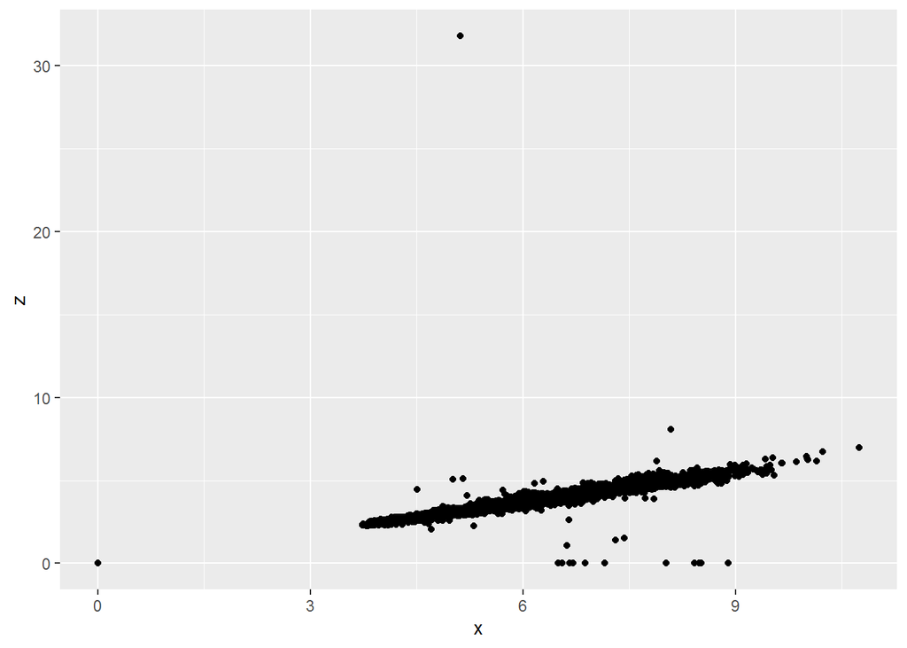

```r
diamonds %>%
  ggplot(aes(x = x, y = z)) +
  geom_point()
```

Passing the `diamonds` data to ggplot, we then just have to set the `x` and `y` values for the plot, in this case the width (`x`) and depth (`z`) columns of our data. Note that the left `x` is the argument of `aes` for what value is that axis for that data point, and the right `x` is the column name in the data.

2. Are there any outlier values? Remove these from the data then re-plot

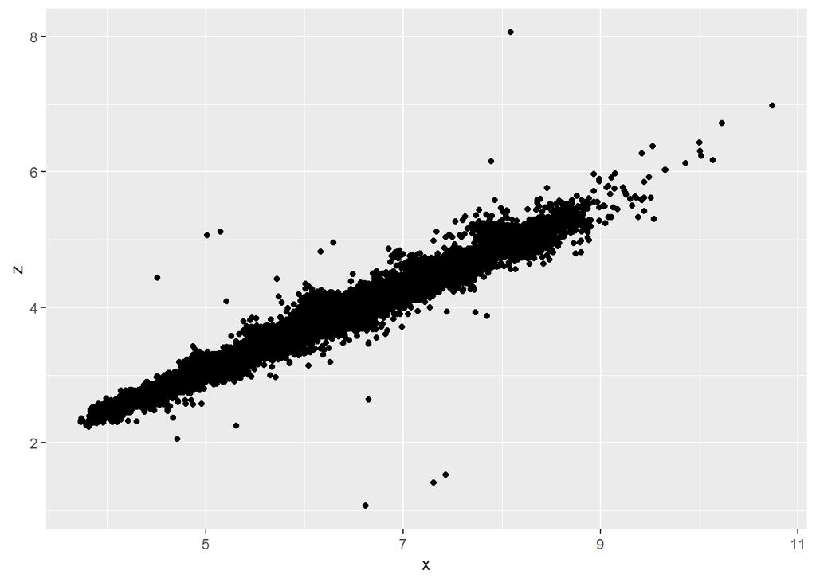

```r
diamonds %>%
  filter(x > 0, z > 0, z < 10) %>%
  ggplot(aes(x = x, y = z)) +
  geom_point()
```

It is quite clear to see there are some diamonds with a 0 measurement in one dimension, and as we aren’t dealing with graphene this isn’t possible. There is also one diamond with a `z` of over 30, which seems wrong. Using pipes we can easily insert a filter into the code and keep the rest the same.

3. Now have the colour of the points vary by clarity

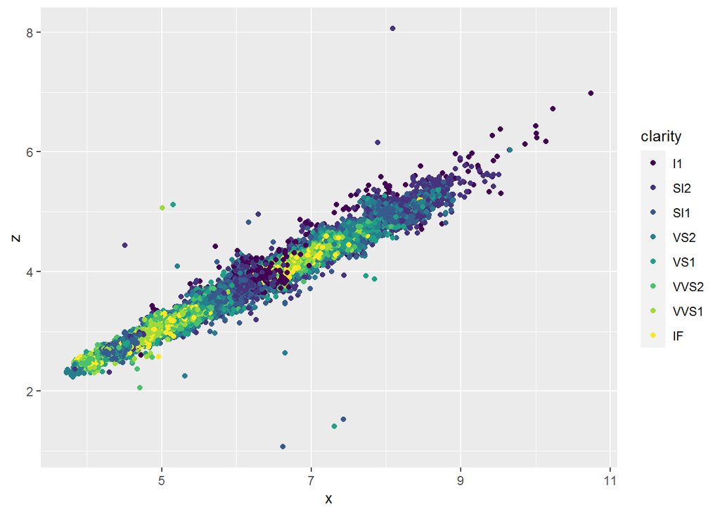

```r
diamonds %>%
  filter(x > 0, z > 0, z < 10) %>%
  ggplot(aes(x = x, y = z, col = clarity)) +
  geom_point()
```

Simply adding `col = clarity` into our aesthetic (not outside of it) sets the colour per point for us.

4. Now have the size of the points vary by carat

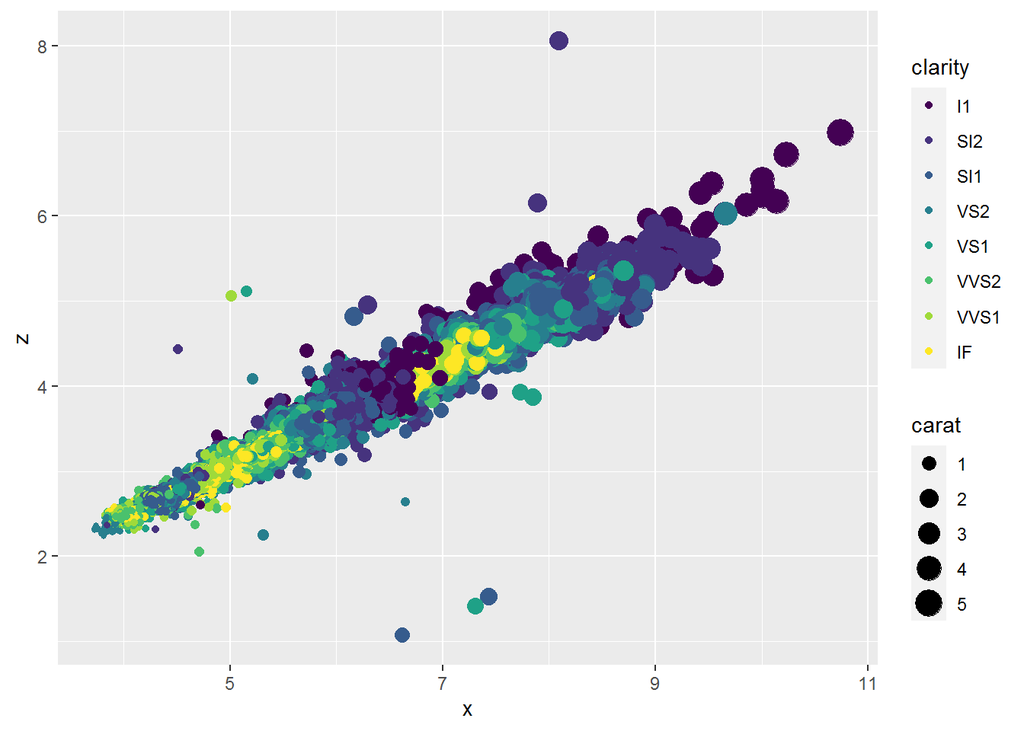

```r
diamonds %>%
  filter(x > 0, z > 0, z < 10) %>%
  ggplot(aes(x = x, y = z, col = clarity, size = carat)) +
  geom_point()
```

Another simple addition to our aesthetic changes the size of the points by carat for us.

5. Label your axis using `xlab()` and `ylab()`, and add a title using `ggtitle()`

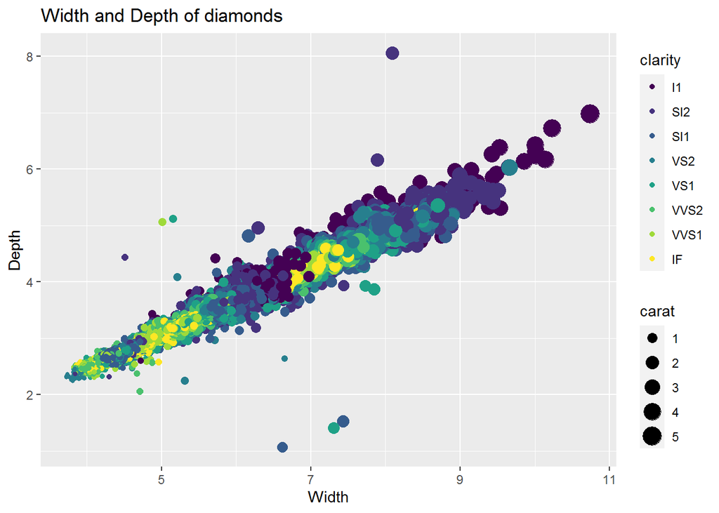

```r
diamonds %>%
  filter(x > 0, z > 0, z < 10) %>%
  ggplot(aes(x = x, y = z, col = clarity, size = carat)) +
  geom_point() +
  xlab('Width') +
  ylab('Depth') +
  ggtitle('Width and Depth of diamonds')
```

Labels are *always* important, otherwise your data means nothing.

6. Run the following lines of code to get a new dataset, there is something hidden in this data, can you find it?

[figure not shown]

```r
source("Image_Challenge/produceImageData.R")
challenge_data <- make_challenge_data()

challenge_data %>% ggplot(aes(x = x,  y = y)) +
  geom_point(alpha = 0.05)
```

By using the `alpha` argument we can find that there is a bird hidden underneath this image!

## GGplot Exercises 2

1. Make a plot using mtcars of hp vs mpg, colour it by cylinder.  
   Can you make the cyl discrete? try `as.character()`

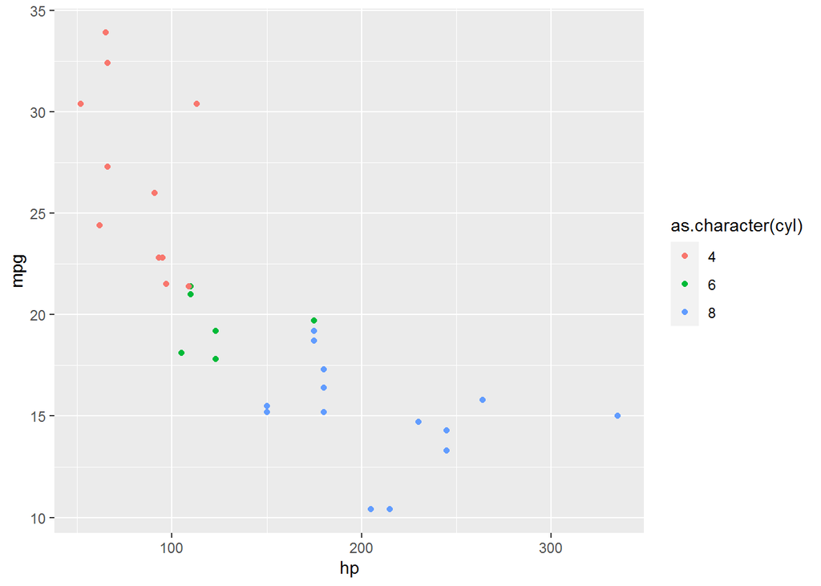

```r
mtcars %>%
  ggplot(aes(x = hp, y = mpg, col = as.character(cyl))) +
  geom_point()
```

The `as.character()` is important as it forces our `cyl` values to be treated as text rather than numbers, meaning they get distinct colours not a range. You could also use `as.factor()` as we will see later.

2. Now split it out into facets by cylinder instead

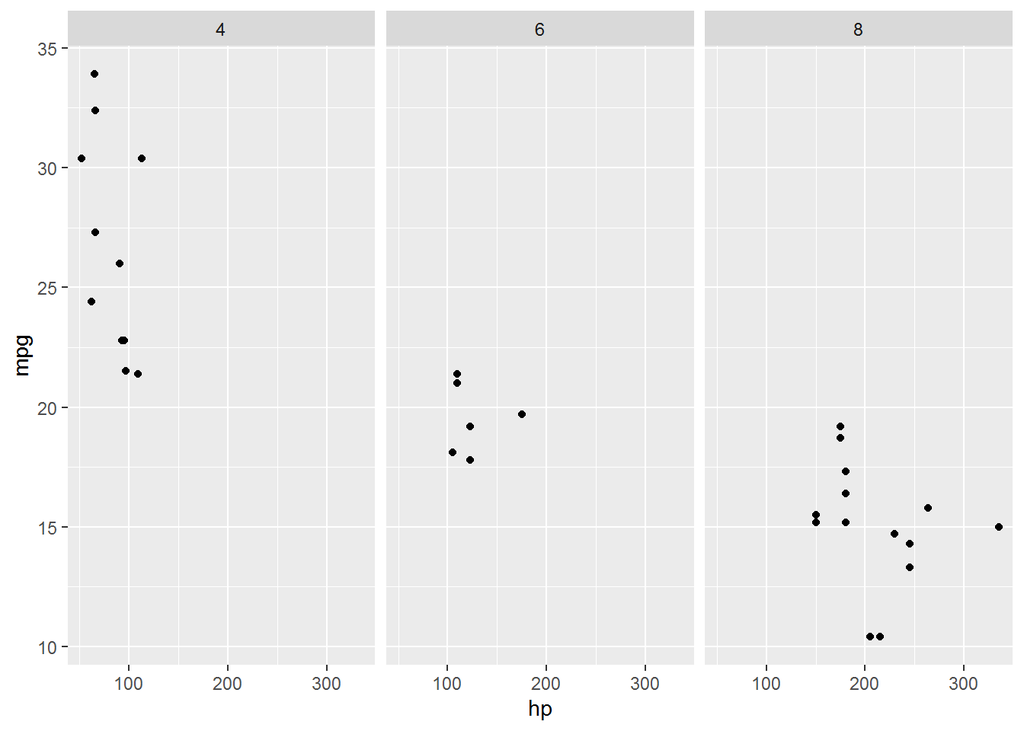

```r
mtcars %>%
  ggplot(aes(x = hp, y = mpg)) +
  geom_point() +
  facet_wrap(~cyl)
```

By adding `facet_wrap` we get 3 different plots now and can examine them separately.

3. Load the `penguins` datasdet and examine it. Plot bill length vs flipper length

```r
library(palmerpenguins)
#?penguins

str(penguins)
```

```
## tibble [344 x 8] (S3: tbl_df/tbl/data.frame)
##  $ species          : Factor w/ 3 levels "Adelie","Chinstrap",..: 1 1 1 1 1 1 1 1 1 1 ...
##  $ island           : Factor w/ 3 levels "Biscoe","Dream",..: 3 3 3 3 3 3 3 3 3 3 ...
##  $ bill_length_mm   : num [1:344] 39.1 39.5 40.3 NA 36.7 39.3 38.9 39.2 34.1 42 ...
##  $ bill_depth_mm    : num [1:344] 18.7 17.4 18 NA 19.3 20.6 17.8 19.6 18.1 20.2 ...
##  $ flipper_length_mm: int [1:344] 181 186 195 NA 193 190 181 195 193 190 ...
##  $ body_mass_g      : int [1:344] 3750 3800 3250 NA 3450 3650 3625 4675 3475 4250 ...
##  $ sex              : Factor w/ 2 levels "female","male": 2 1 1 NA 1 2 1 2 NA NA ...
##  $ year             : int [1:344] 2007 2007 2007 2007 2007 2007 2007 2007 2007 2007 ...
```

```r
head(penguins) %>% nice_format()
```

| species | island | bill_length_mm | bill_depth_mm | flipper_length_mm | body_mass_g | sex | year |
| --- | --- | --- | --- | --- | --- | --- | --- |
| Adelie | Torgersen | 39.1 | 18.7 | 181 | 3750 | male | 2007 |
| Adelie | Torgersen | 39.5 | 17.4 | 186 | 3800 | female | 2007 |
| Adelie | Torgersen | 40.3 | 18.0 | 195 | 3250 | female | 2007 |
| Adelie | Torgersen | NA | NA | NA | NA | NA | 2007 |
| Adelie | Torgersen | 36.7 | 19.3 | 193 | 3450 | female | 2007 |
| Adelie | Torgersen | 39.3 | 20.6 | 190 | 3650 | male | 2007 |

```r
summary(penguins)
```

```
##       species          island    bill_length_mm  bill_depth_mm
##  Adelie   :152   Biscoe   :168   Min.   :32.10   Min.   :13.10
##  Chinstrap: 68   Dream    :124   1st Qu.:39.23   1st Qu.:15.60
##  Gentoo   :124   Torgersen: 52   Median :44.45   Median :17.30
##                                  Mean   :43.92   Mean   :17.15
##                                  3rd Qu.:48.50   3rd Qu.:18.70
##                                  Max.   :59.60   Max.   :21.50
##                                  NA's   :2       NA's   :2
##  flipper_length_mm  body_mass_g       sex           year
##  Min.   :172.0     Min.   :2700   female:165   Min.   :2007
##  1st Qu.:190.0     1st Qu.:3550   male  :168   1st Qu.:2007
##  Median :197.0     Median :4050   NA's  : 11   Median :2008
##  Mean   :200.9     Mean   :4202                Mean   :2008
##  3rd Qu.:213.0     3rd Qu.:4750                3rd Qu.:2009
##  Max.   :231.0     Max.   :6300                Max.   :2009
##  NA's   :2         NA's   :2
```

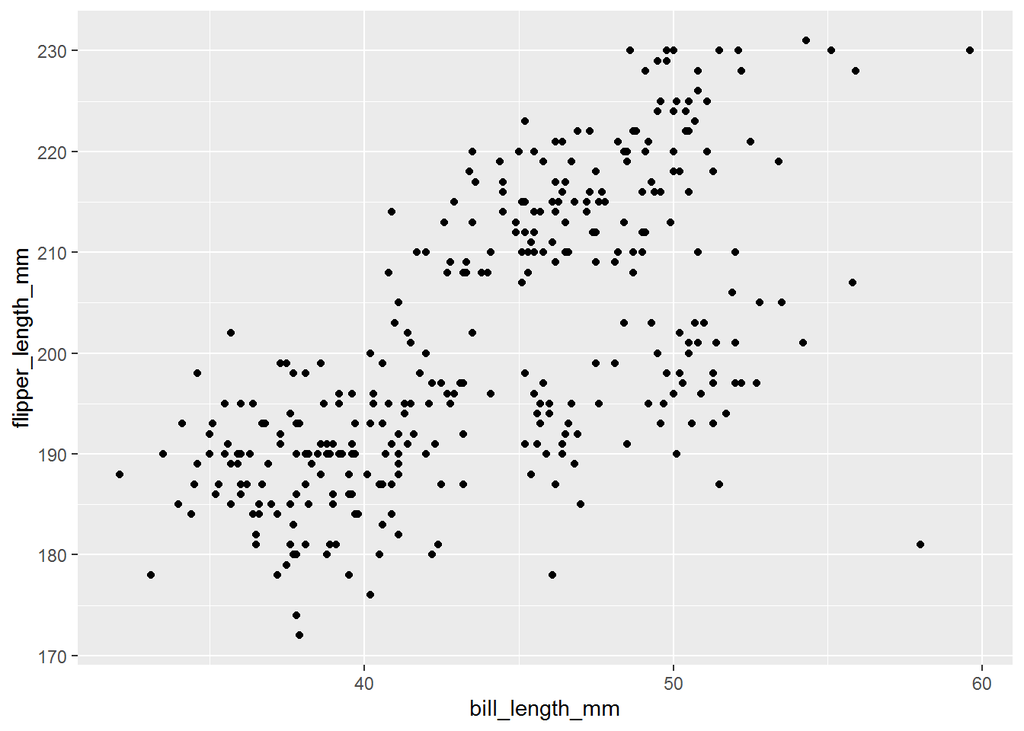

```r
penguins %>%
  ggplot(aes(x = bill_length_mm, y = flipper_length_mm)) +
  geom_point()
```

Our usual basic plot.

4. Now colour it by the species

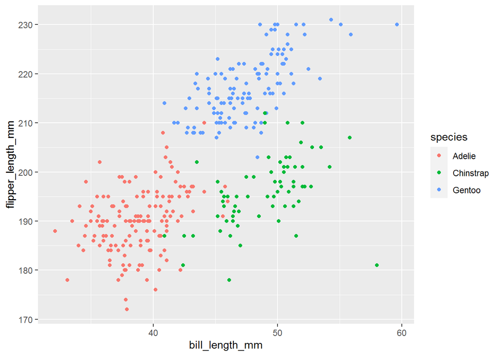

```r
penguins %>%
  ggplot(aes(x = bill_length_mm, y = flipper_length_mm, col = species)) +
  geom_point()
```

Same as before.

5. Now split them out using facets and create a line of best fit for each (think about your scales)  
   Which species seem to follow a linear trend?

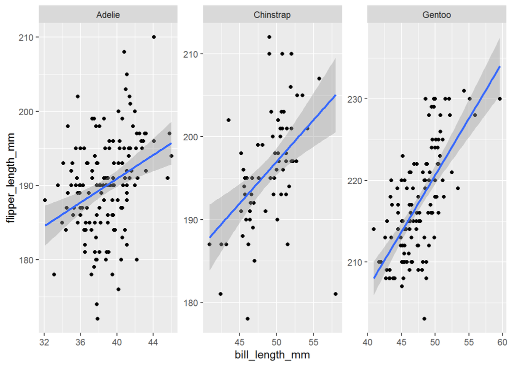

```r
penguins %>%
  ggplot(aes(x = bill_length_mm, y = flipper_length_mm)) +
  geom_point() +
  facet_wrap(~species, scales = 'free') +
  geom_smooth(method = 'lm')
```

Adding `scales = 'free'` is important as the different species have quite different data ranges and this makes it easier for us to view them. We easily added a linear model per species in one line. Both Adelie and Chinstrap don’t seems to follow a linear trend, but Gentoo follows it a bit better.

6. Use the `nycflights13::flights` dataset and see if you can work out how to create a boxplot of arrival delay, by month, setting the y axis limits to between -20 and 20  
   Hint: boxplot only NEEDS a y value

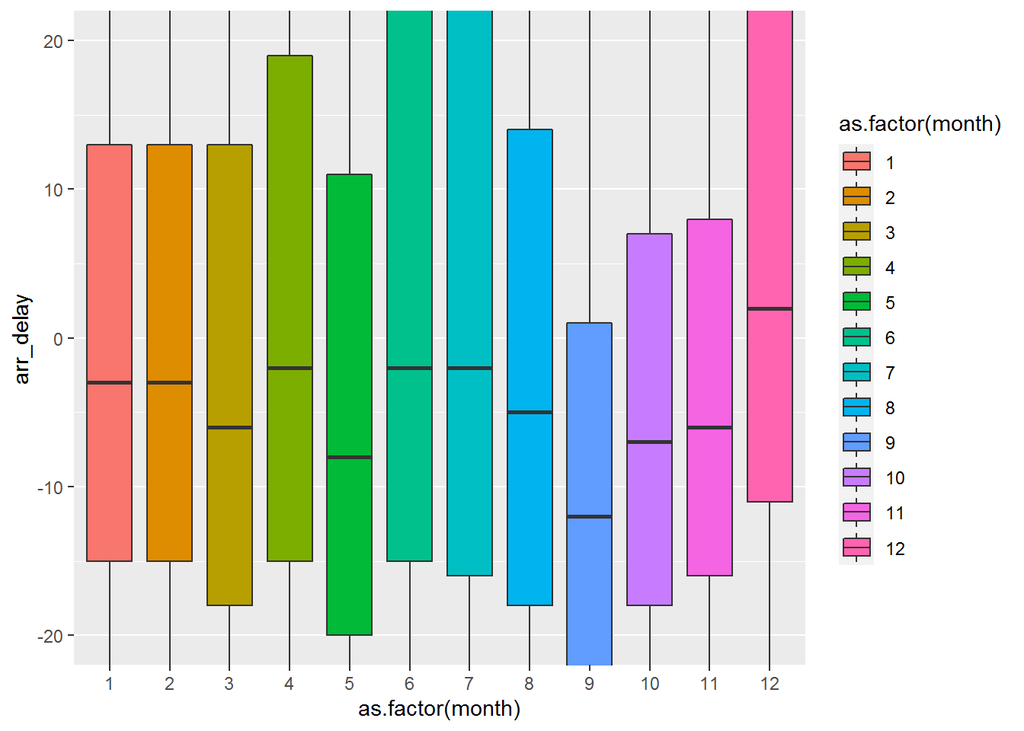

```r
nycflights13::flights %>%
  ggplot(aes(x = as.factor(month), y = arr_delay, group = month, fill = as.factor(month))) +
  geom_boxplot() +
  coord_cartesian(ylim = c(-20, 20))
```

There’s a lot of new stuff here. we use `as.factor()` to convert out month column to a factor rather than a number so that the colours and distinct, and also so the axis displays all values rather than in-between values. We use `fill` rather than `col` as we want to, unsurprisingly, fill the box not colour it. Then we use `geom_boxplot` to make a boxplot, the same way we did a scatter plot. We use `coord_cartesian()` and not `ylim()` as you may see elsewhere as `ylim` is processed before the statistic, `coord_cartesian` is processed after and just crops your view in the chart. Refer back to the grammer of grahpics hierarchy to understand this better. Try it with `ylim` instead and notice the different statistical summaries and results you see.

## Functions conditionals and Loops Exercises

1. Use a `while` loop to print out all the square numbers less than 1061000  
   Bonus to tell me what number squared is the closest but still beneath it

```r
x <- 1
while (x**2 < 1061000){
  print(x**2)
  x <- x + 1
}
x - 1
```

| x |
| --- |
| 1 |
| 4 |
| 9 |
| 16 |
| 25 |
| 36 |
| 49 |
| 64 |
| 81 |
| 100 |
| 121 |
| 144 |
| 169 |
| 196 |
| 225 |
| 256 |
| 289 |
| 324 |
| 361 |
| 400 |
| 441 |
| 484 |
| 529 |
| 576 |
| 625 |
| 676 |
| 729 |
| 784 |
| 841 |
| 900 |

[output cut: 1000 more lines]

```
## [1] 1030
```

We use a `while` loop until the value of `x` squared is greater than 1061000. At this point `x` has been increased by 1 too many so we print 1 less than `x`.

2. Create a variable called `year` and assign this year to it. Now use a conditional statement to test if it is a leap year (evenly divisible by 4, not evenly divisible by 100 unless it is evenly divisible by 400). Check this works for other years to ensure it works.

```r
year <-2020
if (year %% 4 == 0 & (!(year %% 100 == 0) | year %% 400 == 0)){
  print(glue('{year} is a leap year.'))
} else print(glue('{year} is not a leap year.'))
```

```
## 2020 is a leap year.
```

Here we use the `%%` operator which is known as modulo, which returns the remainder of the division between the LHS and RHS; so we use this to check if year is exactly divisible by 4, 100, and 400 (as the remainder is zero). We combine the logic using `&` for and, `|` for or, `!` for not. So we ask if it is divisible by 4 AND (not (divisible by 100) or divisible by 400) then it is a leap year.

The `glue` function from the package for the same name is a useful trick to be able to run `r` code within a string which can save using the `paste` function and make teh code more concise. Notice also we can use the `else` on a single line so we don’t need the curly brackets.

3. Combine a loop and a conditional statement to cycle through all elements in the vector 1:30 and print out each value with whether it is even or odd.

```r
for (i in 1:30){
  if (i %% 2 == 0) print('Even')
  else  print('Odd')
}
```

```
## [1] "Odd"
## [1] "Even"
## [1] "Odd"
## [1] "Even"
## [1] "Odd"
## [1] "Even"
## [1] "Odd"
## [1] "Even"
## [1] "Odd"
## [1] "Even"
## [1] "Odd"
## [1] "Even"
## [1] "Odd"
## [1] "Even"
## [1] "Odd"
## [1] "Even"
## [1] "Odd"
## [1] "Even"
## [1] "Odd"
## [1] "Even"
## [1] "Odd"
## [1] "Even"
## [1] "Odd"
## [1] "Even"
## [1] "Odd"
## [1] "Even"
## [1] "Odd"
## [1] "Even"
## [1] "Odd"
## [1] "Even"
```

The `for` loop executes its code for every element in our sequence which gets assigned to `i` one at a time. Each time round we check if `i` divided by 2 has a remainder (`%%`) of 0, if it does then we return Even, otherwise we return Odd.

4. Take your answer from exercise 2 and instead turn it into a function that takes a value for the year, prints a string telling you if it is a leap year or not, and return TRUE or FALSE

```r
is_leap_year <- function(year){
  if (year %% 4 == 0 & (!(year %% 100 == 0) | year %% 400 == 0)){
    print(glue('{year} is a leap year.'))
    return(TRUE)
  } else {
    print(glue('{year} is not a leap year.'))
    return(FALSE)
  }
}

is_leap_year(2020)
```

```
## 2020 is a leap year.
```

```
## [1] TRUE
```

```r
is_leap_year(2019)
```

```
## 2019 is not a leap year.
```

```
## [1] FALSE
```

```r
is_leap_year(2000)
```

```
## 2000 is a leap year.
```

```
## [1] TRUE
```

```r
is_leap_year(2100)
```

```
## 2100 is not a leap year.
```

```
## [1] FALSE
```

Just adapating the above answer, wrapping it into a function creation, and adding the return functions.

5. Use a while loop to generate the Fibonacci numbers less than 1000

```r
x <- 1
y <- 1
n <- 2
while (x < 1000){
  print(paste("The", n,"th Fibonacci number is", x))
  z <- x
  x <- x + y
  y <- z
  n <- n + 1
}
```

```
## [1] "The 2 th Fibonacci number is 1"
## [1] "The 3 th Fibonacci number is 2"
## [1] "The 4 th Fibonacci number is 3"
## [1] "The 5 th Fibonacci number is 5"
## [1] "The 6 th Fibonacci number is 8"
## [1] "The 7 th Fibonacci number is 13"
## [1] "The 8 th Fibonacci number is 21"
## [1] "The 9 th Fibonacci number is 34"
## [1] "The 10 th Fibonacci number is 55"
## [1] "The 11 th Fibonacci number is 89"
## [1] "The 12 th Fibonacci number is 144"
## [1] "The 13 th Fibonacci number is 233"
## [1] "The 14 th Fibonacci number is 377"
## [1] "The 15 th Fibonacci number is 610"
## [1] "The 16 th Fibonacci number is 987"
```

The Fibonacci sequence is defined as F(1) = F(2) = 1 and F(n) = F(n-1) + F(n-2). So we initialise `x` and `y` as F(1) and F(2), and n = 2. So, to calculate F(3) we need to add F(2) and F(1). We store F(2) in `z` temporarily, store F(3) in `x` and then store F(2) in `y`, and finally increment `n`. We can then keep doing this until `x` which is F(n) is greater than 1000.

6. Create a function that takes a value, n, and returns that Fibonacci number

```r
# Recursive method
fibo_rec <- function(n) {
  if (n == 2 | n == 1) return(1)
  else return(fibo_rec(n-1) + fibo_rec(n-2))
}

# Iterative method
fibo_iter <- function(n) {
  if (n == 2 | n == 1) return(1)
  else{
    x <- 1
    y <- 1
    i <- 2
    while (i < n){
      z <- x
      x <- x + y
      y <- z
      i <- i + 1
    }
  return(x)
  }
}


# Check they work
for(i in 1:20){
  print(paste(fibo_rec(i), fibo_iter(i)))
}
```

```
## [1] "1 1"
## [1] "1 1"
## [1] "2 2"
## [1] "3 3"
## [1] "5 5"
## [1] "8 8"
## [1] "13 13"
## [1] "21 21"
## [1] "34 34"
## [1] "55 55"
## [1] "89 89"
## [1] "144 144"
## [1] "233 233"
## [1] "377 377"
## [1] "610 610"
## [1] "987 987"
## [1] "1597 1597"
## [1] "2584 2584"
## [1] "4181 4181"
## [1] "6765 6765"
```

There’s 2 basic ways to calculate the nth Fibonacci number (without doing dynamic programming) that is pretty much either work up or work down. The first method works down, starting with the definition of F(n) = F(n-1) + F(n-2) until it hits one of the base cases, calling itself until it gets to a base case. This is known as recursion and will not be covered here but many resources are available on the topic.

The second method works up, using the same approach as above but with a check on the counter rather than the result this time.